# Spring’21 IE360 HW 2

### 2017402180

# 1) Introduction

In this assignment, our goal is to forecast the CPI (Food and Non-Alcoholic Beverages), using some economic measures. By using the regressors and the target variable, we will create a time series regression model to forecast the future month.

My target variable in this study is the CPI (Food and Non-Alcoholic Beverages) in Turkey and the independent variables are: USD/TRY Exchange Rate, Interest Rates and Domestic PPI (Producer Price Index). By inspecting the relationships and correlations between the target variable and the independent variables, the final model will be created.

In addition to these, it will be decided which time series components and lag values should be included in the model and the model will be created. At each step, the model performance values will be evaluated and whether the assumptions about residuals are met or not. Recall that the assumptions about residuals are:

• Residuals are normally distributed with zero mean and constant variance.

• Residuals are not autocorrelated.

# 2) Analysis

• The time series data are imported from EVDS. Required packages are downloaded and the data is manipulated into a proper format for future operations.

```r
library(readxl)
library(data.table)
library(forecast)
library(lubridate)
library(ggplot2)
library(scales)
library(stats)
library(GGally)

alldata=read_excel("EVDS-AllData.xlsx")
alldata=as.data.table(alldata)
alldata$Date=as.Date(alldata$Date)
head(alldata)
```

```
##          Date    CPI InterestRates USDexchange DomesticPPI
## 1: 2008-01-01 147.21       18.4675    1.170436    143.7987
## 2: 2008-02-01 154.65       18.3780    1.188171    147.4833
## 3: 2008-03-01 156.26       19.1275    1.232376    152.1584
## 4: 2008-04-01 157.84       19.8225    1.296714    159.0026
## 5: 2008-05-01 158.24       19.5160    1.246995    162.3703
## 6: 2008-06-01 152.86       19.8725    1.227800    162.8953
```

```r
str(alldata)
```

```
## Classes 'data.table' and 'data.frame':   159 obs. of  5 variables:
##  $ Date         : Date, format: "2008-01-01" "2008-02-01" ...
##  $ CPI          : num  147 155 156 158 158 ...
##  $ InterestRates: num  18.5 18.4 19.1 19.8 19.5 ...
##  $ USDexchange  : num  1.17 1.19 1.23 1.3 1.25 ...
##  $ DomesticPPI  : num  144 147 152 159 162 ...
##  - attr(*, ".internal.selfref")=<externalptr>
```

## 2.1) Target Variable Visualizaiton

• Visualizing the target variable over time is very useful in order to understand its behavior.

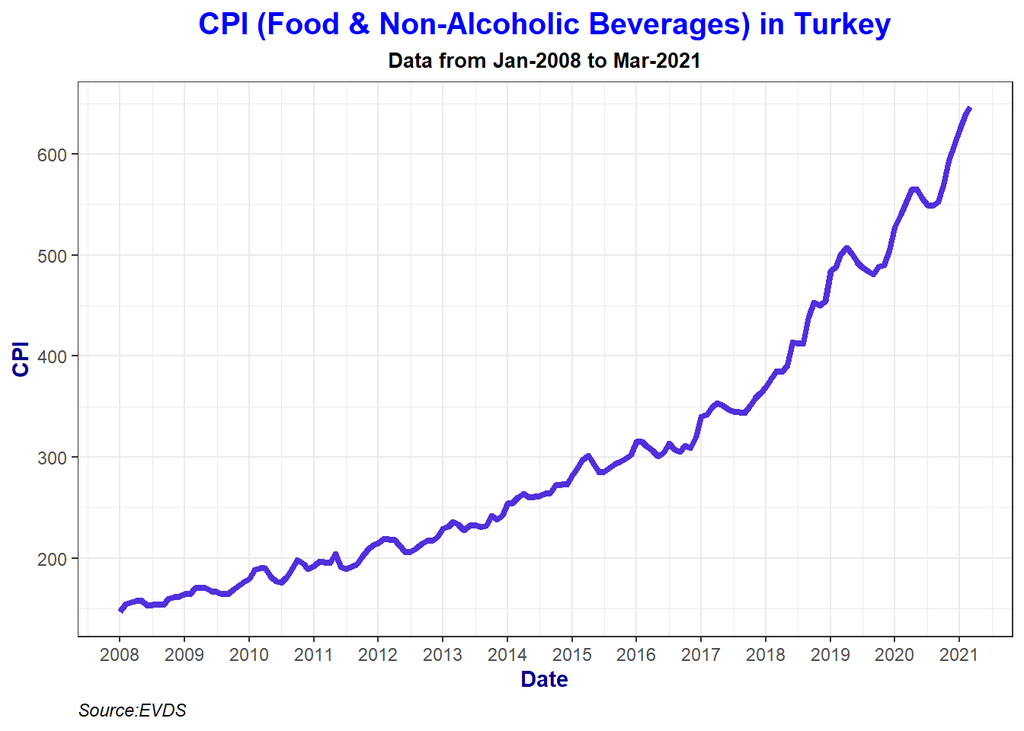

```r
ggplot(data=alldata, aes(x=Date, y=CPI))+geom_line(size=1.5,colour="#512FDC")+
  theme_bw()+
  labs(title = "CPI (Food & Non-Alcoholic Beverages) in Turkey", x = "Date",subtitle = "Data from Jan-2008 to Mar-2021",caption = "Source:EVDS") +
  theme(axis.title.y = element_text(color = "dark blue", face = "bold"),plot.title = element_text(color = "blue", size = 15, face = "bold",hjust=0.5),
        plot.subtitle = element_text(size = 10, face = "bold", hjust = 0.5), axis.title.x=element_text(colour="Dark Blue", face="bold"),
        plot.caption = element_text(face = "italic", hjust = 0))+
  scale_x_date(date_breaks = "1 year",labels=date_format("%Y"))
```

• Taking the logarithm of our target value:CPI is benefical in that case since it helps linearizing our target variable.

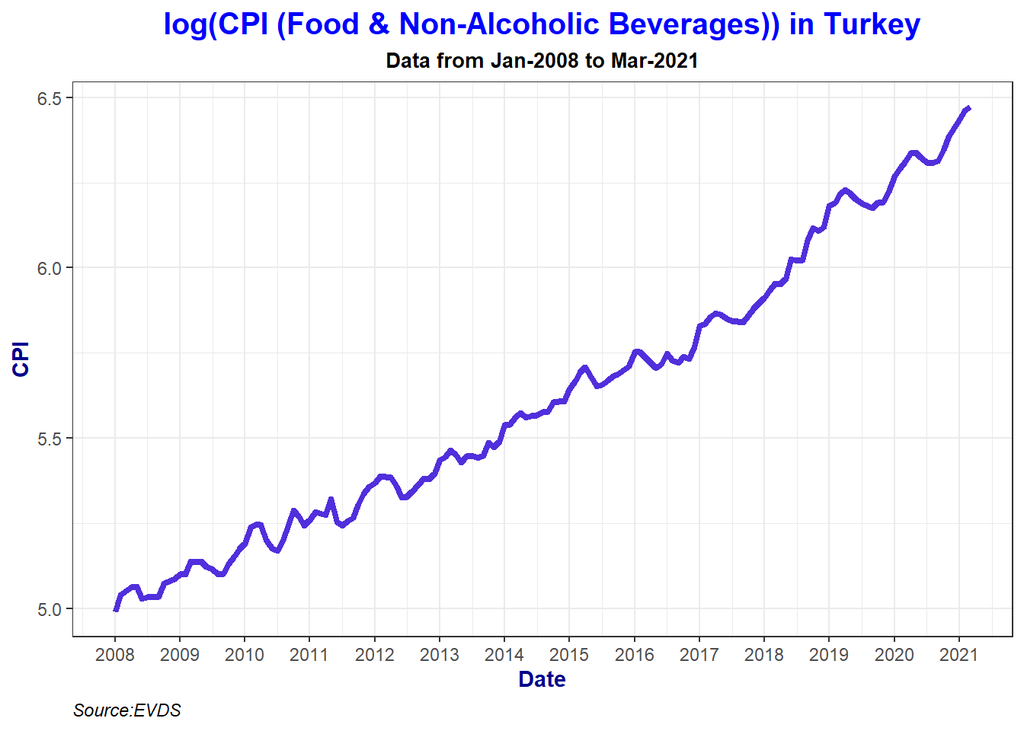

```r
alldata$CPI=log(alldata$CPI)
ggplot(data=alldata, aes(x=Date, y=CPI))+geom_line(size=1.5,colour="#512FDC")+
  theme_bw()+
  labs(title = "log(CPI (Food & Non-Alcoholic Beverages)) in Turkey", x = "Date",subtitle = "Data from Jan-2008 to Mar-2021",caption = "Source:EVDS") +
  theme(axis.title.y = element_text(color = "dark blue", face = "bold"),plot.title = element_text(color = "blue", size = 15, face = "bold",hjust=0.5),
        plot.subtitle = element_text(size = 10, face = "bold", hjust = 0.5), axis.title.x=element_text(colour="Dark Blue", face="bold"),
        plot.caption = element_text(face = "italic", hjust = 0))+
  scale_x_date(date_breaks = "1 year",labels=date_format("%Y"))
```

• After taking the logarithm of CPI, it is easily seen that the plot is switched to a more linear one.

## 2.2) Visualization of Independent Variables

• Using the ‘ggpairs’ function, we are able to inspect the correlation between all variables, pdf of variables and the scatterplots between variables.

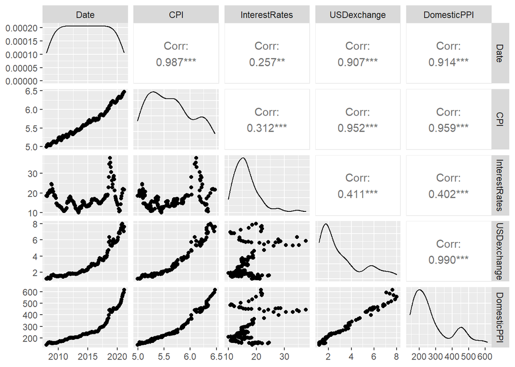

```r
ggpairs(alldata)
```

• When we inspect the highest correlated pairs: USDExchange-CPI (corr: 0.952) and PPI-CPI (corr: 0.959), we observe that the scatterplots of pairs are very close to linear and this verifies our claim that the independent variables chosen are relevant and good predictors for our target variable.

• As well as the CPI variable, USD Exchange Rate and PPI variables also display a nonlinear behavior over time. By taking the logarithms of these variables we might improve our model. When the logarithm of these values are plotted with their original values, it is easily seen that both variables have become more linear with this operation.

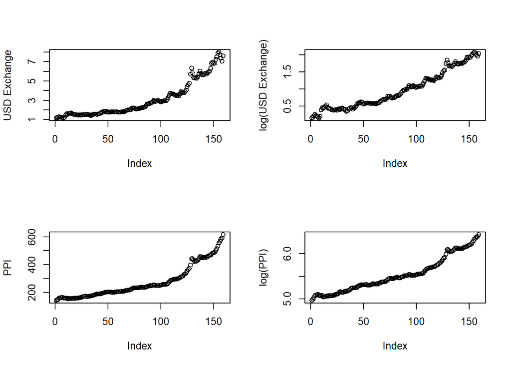

```r
par(mfrow=c(2,2))
plot(alldata$USDexchange, ylab="USD Exchange")
plot(log(alldata$USDexchange), ylab="log(USD Exchange)")


plot(alldata$DomesticPPI, ylab="PPI")
plot(log(alldata$DomesticPPI),ylab="log(PPI)")
```

• Compared with the previous plots, logarithmic plots of `USDDexchange` and `DomesticPPI`are more linear, thus preferable for us.

## 2.3) Time Series Modelling

### 2.3.1) Trend Component

• Since we know that both the CPI and and log(CPI) increase in time, we can start by adding a trend variable to decompose the trend component of the time series regression model.

```r
alldata[,trend:=1:.N]

ts_reg=lm(log(CPI)~trend, alldata)
summary(ts_reg)
```

```
##
## Call:
## lm(formula = log(CPI) ~ trend, data = alldata)
##
## Residuals:
##        Min         1Q     Median         3Q        Max
## -0.0197263 -0.0074580 -0.0009069  0.0068488  0.0209612
##
## Coefficients:
##              Estimate Std. Error t value Pr(>|t|)
## (Intercept) 1.601e+00  1.518e-03 1054.63   <2e-16 ***
## trend       1.545e-03  1.646e-05   93.85   <2e-16 ***
## ---
## Signif. codes:  0 '***' 0.001 '**' 0.01 '*' 0.05 '.' 0.1 ' ' 1
##
## Residual standard error: 0.009525 on 157 degrees of freedom
## Multiple R-squared:  0.9825, Adjusted R-squared:  0.9824
## F-statistic:  8807 on 1 and 157 DF,  p-value: < 2.2e-16
```

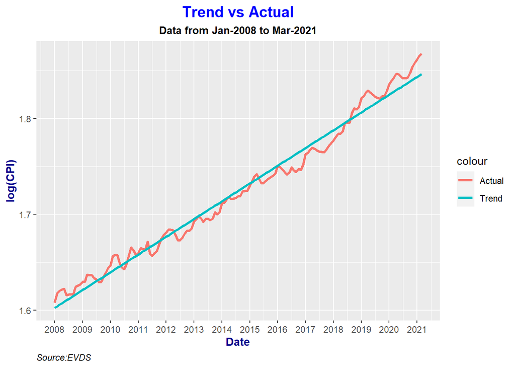

```r
alldata[,trend_constant:=predict(ts_reg,alldata)]

ggplot(data=alldata, aes(x=Date))+ geom_line(aes(y=log(CPI),color="Actual"),size=1.2)+
  geom_line(aes(y=trend_constant,color='Trend'),size=1.2)+
  labs(title = "Trend vs Actual", x = "Date",subtitle = "Data from Jan-2008 to Mar-2021",caption = "Source:EVDS") +
  theme(axis.title.y = element_text(color = "dark blue", face = "bold"),plot.title = element_text(color = "blue", size = 15, face = "bold",hjust=0.5),
        plot.subtitle = element_text(size = 10, face = "bold", hjust = 0.5), axis.title.x=element_text(colour="Dark Blue", face="bold"),
        plot.caption = element_text(face = "italic", hjust = 0))+
  scale_x_date(date_breaks = "1 year",labels=date_format("%Y"))
```

• When our model’s predictions and the actual observations are plotted together, we observe that even a simple trend variable very helpful in predicting the log of the prices.

• Our adjusted R^2 value is relatively high and p value is very significant, which shows the succes of adding the trend variable.

### 2.3.2) Month Component

• By adding a month variable, we may be able to model the seasonality of our target variable.

```r
alldata[,month:=as.character(month(Date,label=1))]

ts_reg=lm(log(CPI)~trend+month,alldata)
summary(ts_reg)
```

```
##
## Call:
## lm(formula = log(CPI) ~ trend + month, data = alldata)
##
## Residuals:
##       Min        1Q    Median        3Q       Max
## -0.017978 -0.006507 -0.001582  0.007994  0.017049
##
## Coefficients:
##              Estimate Std. Error t value Pr(>|t|)
## (Intercept) 1.595e+00  2.787e-03 572.402  < 2e-16 ***
## trend       1.546e-03  1.555e-05  99.359  < 2e-16 ***
## monthAra    4.441e-03  3.527e-03   1.259 0.210079
## monthEki    4.030e-03  3.527e-03   1.143 0.255082
## monthEyl    6.360e-04  3.527e-03   0.180 0.857152
## monthHaz    2.850e-03  3.527e-03   0.808 0.420377
## monthKas    3.689e-03  3.527e-03   1.046 0.297322
## monthMar    1.164e-02  3.463e-03   3.361 0.000993 ***
## monthMay    6.722e-03  3.527e-03   1.906 0.058644 .
## monthNis    9.632e-03  3.527e-03   2.731 0.007102 **
## monthOca    8.865e-03  3.463e-03   2.560 0.011492 *
## monthŞub    1.078e-02  3.463e-03   3.111 0.002241 **
## monthTem    1.146e-03  3.527e-03   0.325 0.745614
## ---
## Signif. codes:  0 '***' 0.001 '**' 0.01 '*' 0.05 '.' 0.1 ' ' 1
##
## Residual standard error: 0.008992 on 146 degrees of freedom
## Multiple R-squared:  0.9855, Adjusted R-squared:  0.9843
## F-statistic: 826.1 on 12 and 146 DF,  p-value: < 2.2e-16
```

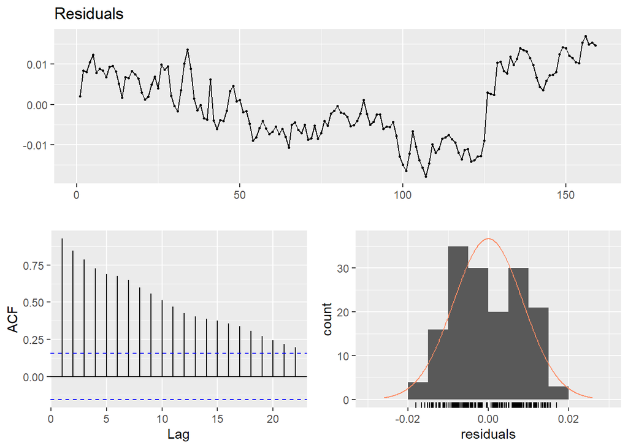

```r
checkresiduals(ts_reg$residuals,lag=12)
```

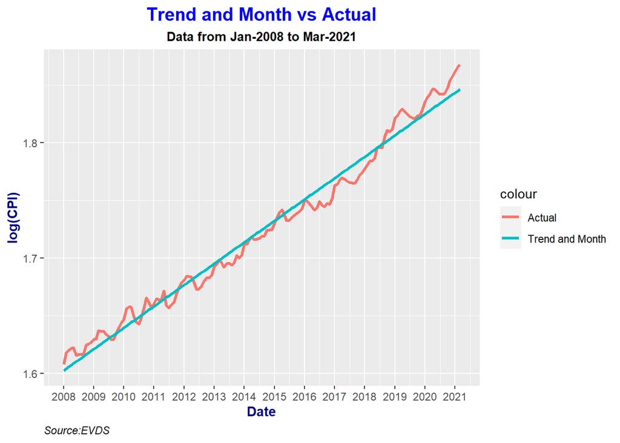

```r
alldata[,trend_constant_month:=predict(ts_reg,alldata)]

ggplot(data=alldata, aes(x=Date))+ geom_line(aes(y=log(CPI),color="Actual"),size=1.2)+
  geom_line(aes(y=trend_constant,color='Trend and Month'),size=1.2)+
  labs(title = "Trend and Month vs Actual", x = "Date",subtitle = "Data from Jan-2008 to Mar-2021",caption = "Source:EVDS") +
  theme(axis.title.y = element_text(color = "dark blue", face = "bold"),plot.title = element_text(color = "blue", size = 15, face = "bold",hjust=0.5),
        plot.subtitle = element_text(size = 10, face = "bold", hjust = 0.5), axis.title.x=element_text(colour="Dark Blue", face="bold"),
        plot.caption = element_text(face = "italic", hjust = 0))+
  scale_x_date(date_breaks = "1 year",labels=date_format("%Y"))
```

• Since our Adjusted R^2 value is better wrt to the previous, we will proceed with the current model.

• By inspecting the `checkresiduals()` function’s output, it is clear that the linear regression assumptions are violated and there is a high autocorrelation between predictions, all those indicate that our model needs more correction.

### 2.3.3) USD/TRY Exchange Rate

• In order to improve our model, the selected regressor USD/TRY Exchange Rate should be added to the model.

• As mentioned earlier, the time series distribution of `USDexchange` is not linear and it can become more linear by taking its logarithm. When we check the correlations with our target variable: `log(CPI)` for `USDexchange` and `log(USDexchange)`, it is seen that the correlation is higher when we take the logarithm of the independent variable so we decide to use the logarithmic function.

```r
cor(log(alldata$USDexchange),log(alldata$CPI))
```

```
## [1] 0.9841421
```

```r
cor(alldata$USDexchange,log(alldata$CPI))
```

```
## [1] 0.9427861
```

```r
ts_reg=lm(log(CPI)~trend+month+log(USDexchange),alldata)
summary(ts_reg)
```

```
##
## Call:
## lm(formula = log(CPI) ~ trend + month + log(USDexchange), data = alldata)
##
## Residuals:
##        Min         1Q     Median         3Q        Max
## -0.0134120 -0.0037720  0.0004841  0.0036919  0.0180369
##
## Coefficients:
##                    Estimate Std. Error t value Pr(>|t|)
## (Intercept)       1.594e+00  1.796e-03 887.574  < 2e-16 ***
## trend             9.739e-04  4.090e-05  23.813  < 2e-16 ***
## monthAra          3.812e-03  2.270e-03   1.680 0.095203 .
## monthEki          3.221e-03  2.270e-03   1.419 0.158037
## monthEyl         -1.291e-05  2.269e-03  -0.006 0.995469
## monthHaz          2.863e-03  2.269e-03   1.262 0.209014
## monthKas          3.060e-03  2.270e-03   1.348 0.179627
## monthMar          1.047e-02  2.230e-03   4.695 6.13e-06 ***
## monthMay          6.433e-03  2.269e-03   2.835 0.005239 **
## monthNis          9.384e-03  2.269e-03   4.135 5.98e-05 ***
## monthOca          7.798e-03  2.229e-03   3.498 0.000623 ***
## monthŞub          1.020e-02  2.228e-03   4.576 1.01e-05 ***
## monthTem          1.643e-03  2.269e-03   0.724 0.470330
## log(USDexchange)  4.954e-02  3.437e-03  14.414  < 2e-16 ***
## ---
## Signif. codes:  0 '***' 0.001 '**' 0.01 '*' 0.05 '.' 0.1 ' ' 1
##
## Residual standard error: 0.005785 on 145 degrees of freedom
## Multiple R-squared:  0.994,  Adjusted R-squared:  0.9935
## F-statistic:  1859 on 13 and 145 DF,  p-value: < 2.2e-16
```

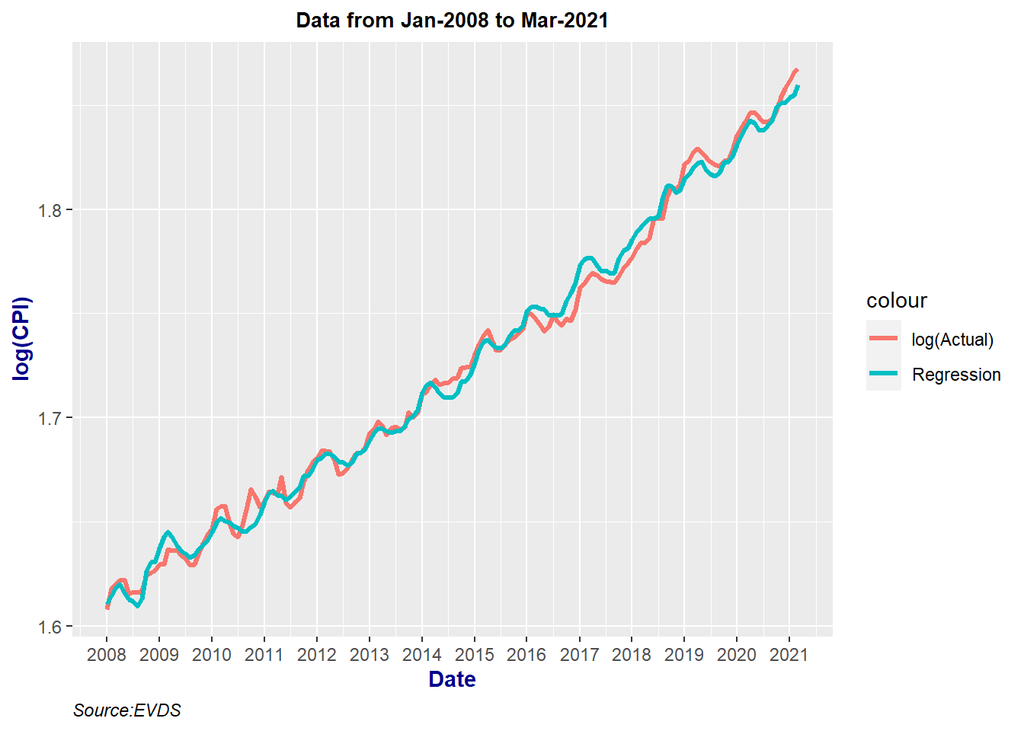

```r
alldata[,regrline:=predict(ts_reg,alldata)]

ggplot(data=alldata, aes(x=Date))+ geom_line(aes(y=log(CPI),color="log(Actual)"),size=1.2)+
  geom_line(aes(y=regrline,color='Regression'),size=1.2)+
  labs(x = "Date",subtitle = "Data from Jan-2008 to Mar-2021",caption = "Source:EVDS") +
  theme(axis.title.y = element_text(color = "dark blue", face = "bold"),plot.title = element_text(color = "blue", size = 15, face = "bold",hjust=0),
        plot.subtitle = element_text(size = 10, face = "bold", hjust = 0.5), axis.title.x=element_text(colour="Dark Blue", face="bold"),
        plot.caption = element_text(face = "italic", hjust = 0))+
  scale_x_date(date_breaks = "1 year",labels=date_format("%Y"))
```

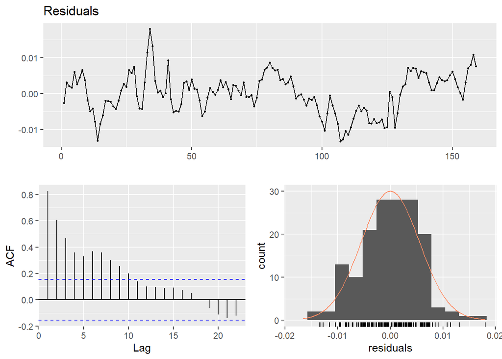

```r
checkresiduals(ts_reg$residuals)
```

• When compared with the previous model, our adjusted R^2 value has increased, and the p-value of the `log(USDexchange` is significant. • The plot of the current regression model with the actual data also displays that our model has improved by the addition of the variable. • Even though our zero mean and constant variance assumptions for the residuals seem to improve, and the histogram of the residuals is in a closer shape to the normal distribution, there still is a high auto correlation and residuals can be further improved.

### 2.3.4) Domestic PPI (Producer Price Index)

• Similar to the variable USDexhange, DomesticPPI also has a nonlinear distribution and taking the natural logarithm of the variable relatively linearizes it. Also when we check the correlations, we see that chosing the logarithmic version is more beneficial for the model

```r
cor(log(alldata$DomesticPPI),log(alldata$CPI))
```

```
## [1] 0.9865568
```

```r
cor(alldata$DomesticPPI,log(alldata$CPI))
```

```
## [1] 0.9502182
```

```r
ts_reg=lm(log(CPI)~trend+month+log(USDexchange)+log(DomesticPPI),alldata)
summary(ts_reg)
```

```
##
## Call:
## lm(formula = log(CPI) ~ trend + month + log(USDexchange) + log(DomesticPPI),
##     data = alldata)
##
## Residuals:
##        Min         1Q     Median         3Q        Max
## -0.0088838 -0.0027232 -0.0001736  0.0024426  0.0139613
##
## Coefficients:
##                   Estimate Std. Error t value Pr(>|t|)
## (Intercept)      1.273e+00  2.650e-02  48.056  < 2e-16 ***
## trend            8.746e-04  3.003e-05  29.122  < 2e-16 ***
## monthAra         4.219e-03  1.604e-03   2.631 0.009450 **
## monthEki         3.267e-03  1.603e-03   2.038 0.043405 *
## monthEyl         8.457e-06  1.603e-03   0.005 0.995798
## monthHaz         2.598e-03  1.603e-03   1.621 0.107273
## monthKas         3.157e-03  1.603e-03   1.969 0.050885 .
## monthMar         1.006e-02  1.575e-03   6.385 2.21e-09 ***
## monthMay         6.133e-03  1.603e-03   3.826 0.000194 ***
## monthNis         9.185e-03  1.603e-03   5.729 5.69e-08 ***
## monthOca         7.846e-03  1.575e-03   4.982 1.78e-06 ***
## monthŞub         9.706e-03  1.575e-03   6.164 6.76e-09 ***
## monthTem         1.334e-03  1.603e-03   0.832 0.406794
## log(USDexchange) 1.234e-02  3.916e-03   3.152 0.001971 **
## log(DomesticPPI) 6.587e-02  5.440e-03  12.107  < 2e-16 ***
## ---
## Signif. codes:  0 '***' 0.001 '**' 0.01 '*' 0.05 '.' 0.1 ' ' 1
##
## Residual standard error: 0.004086 on 144 degrees of freedom
## Multiple R-squared:  0.997,  Adjusted R-squared:  0.9968
## F-statistic:  3469 on 14 and 144 DF,  p-value: < 2.2e-16
```

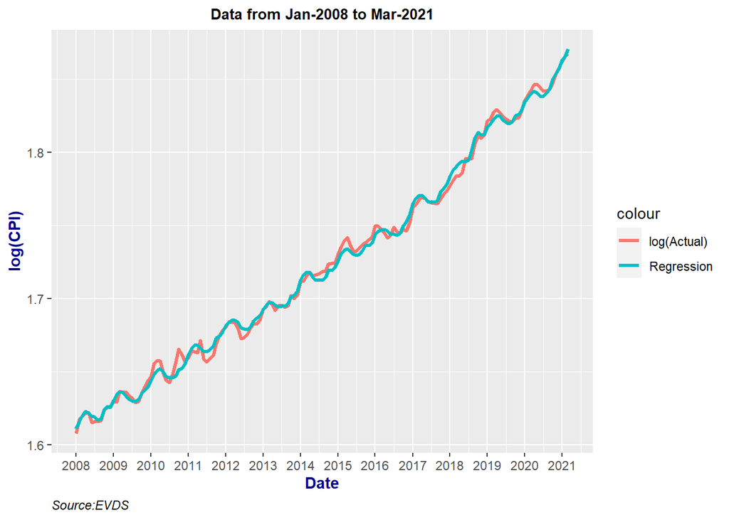

```r
alldata[,regrline:=predict(ts_reg,alldata)]

ggplot(data=alldata, aes(x=Date))+ geom_line(aes(y=log(CPI),color="log(Actual)"),size=1.2)+
  geom_line(aes(y=regrline,color='Regression'),size=1.2)+
  labs(x = "Date",subtitle = "Data from Jan-2008 to Mar-2021",caption = "Source:EVDS") +
  theme(axis.title.y = element_text(color = "dark blue", face = "bold"),plot.title = element_text(color = "blue", size = 15, face = "bold",hjust=0.5),
        plot.subtitle = element_text(size = 10, face = "bold", hjust = 0.5), axis.title.x=element_text(colour="Dark Blue", face="bold"),
        plot.caption = element_text(face = "italic", hjust = 0))+
  scale_x_date(date_breaks = "1 year",labels=date_format("%Y"))
```

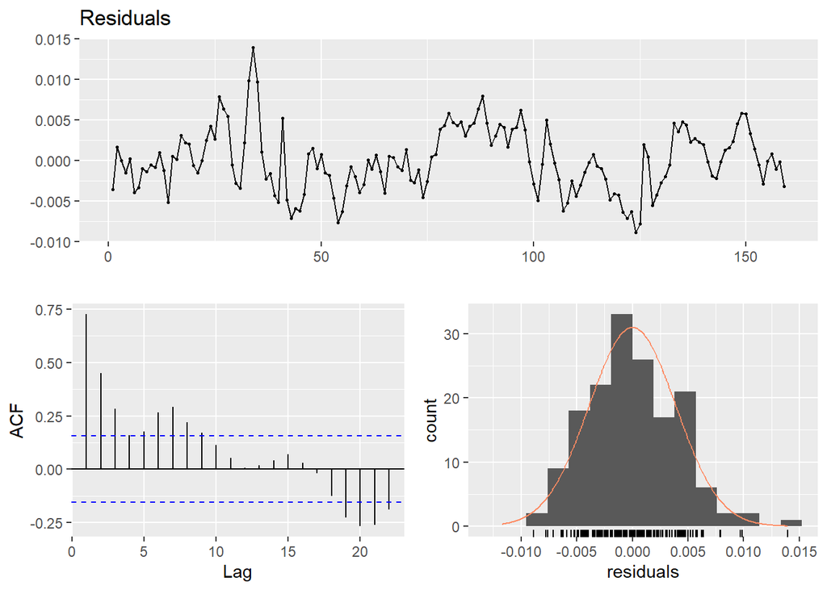

```r
checkresiduals(ts_reg$residuals)
```

• With the addition of the new variable, our adjusted R^2 value has increased and when the `summary` function is inspected, we see that our regressor is significant.

• Zero mean assumption for the residuals seem to hold slightly better. The plot also displays that our model mostly fits the actual data.

### 2.3.5) Interest Rate

• The final data which we will add to our model is `Interest Rate`.

```r
ts_reg=lm(log(CPI)~trend+month+log(USDexchange)+log(DomesticPPI)+InterestRates,alldata)
summary(ts_reg)
```

```
##
## Call:
## lm(formula = log(CPI) ~ trend + month + log(USDexchange) + log(DomesticPPI) +
##     InterestRates, data = alldata)
##
## Residuals:
##        Min         1Q     Median         3Q        Max
## -0.0082842 -0.0028083 -0.0001233  0.0023936  0.0133369
##
## Coefficients:
##                    Estimate Std. Error t value Pr(>|t|)
## (Intercept)       1.271e+00  2.607e-02  48.752  < 2e-16 ***
## trend             8.298e-04  3.482e-05  23.833  < 2e-16 ***
## monthAra          4.226e-03  1.577e-03   2.680 0.008224 **
## monthEki          3.301e-03  1.577e-03   2.094 0.038049 *
## monthEyl          8.352e-06  1.576e-03   0.005 0.995780
## monthHaz          2.483e-03  1.577e-03   1.575 0.117541
## monthKas          3.209e-03  1.577e-03   2.035 0.043672 *
## monthMar          9.887e-03  1.551e-03   6.376 2.35e-09 ***
## monthMay          5.978e-03  1.578e-03   3.789 0.000222 ***
## monthNis          9.010e-03  1.578e-03   5.710 6.31e-08 ***
## monthOca          7.833e-03  1.549e-03   5.058 1.28e-06 ***
## monthŞub          9.643e-03  1.549e-03   6.227 4.99e-09 ***
## monthTem          1.331e-03  1.576e-03   0.844 0.400043
## log(USDexchange)  1.598e-02  4.131e-03   3.869 0.000166 ***
## log(DomesticPPI)  6.692e-02  5.367e-03  12.468  < 2e-16 ***
## InterestRates    -2.034e-04  8.363e-05  -2.433 0.016228 *
## ---
## Signif. codes:  0 '***' 0.001 '**' 0.01 '*' 0.05 '.' 0.1 ' ' 1
##
## Residual standard error: 0.004018 on 143 degrees of freedom
## Multiple R-squared:  0.9972, Adjusted R-squared:  0.9969
## F-statistic:  3349 on 15 and 143 DF,  p-value: < 2.2e-16
```

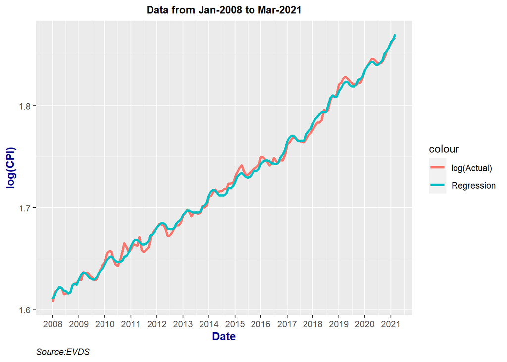

```r
alldata[,regrline:=predict(ts_reg,alldata)]

ggplot(data=alldata, aes(x=Date))+ geom_line(aes(y=log(CPI),color="log(Actual)"),size=1.2)+
  geom_line(aes(y=regrline,color='Regression'),size=1.2)+
  labs(x = "Date",subtitle = "Data from Jan-2008 to Mar-2021",caption = "Source:EVDS") +
  theme(axis.title.y = element_text(color = "dark blue", face = "bold"),plot.title = element_text(color = "blue", size = 15, face = "bold",hjust=0.5),
        plot.subtitle = element_text(size = 10, face = "bold", hjust = 0.5), axis.title.x=element_text(colour="Dark Blue", face="bold"),
        plot.caption = element_text(face = "italic", hjust = 0))+
  scale_x_date(date_breaks = "1 year",labels=date_format("%Y"))
```

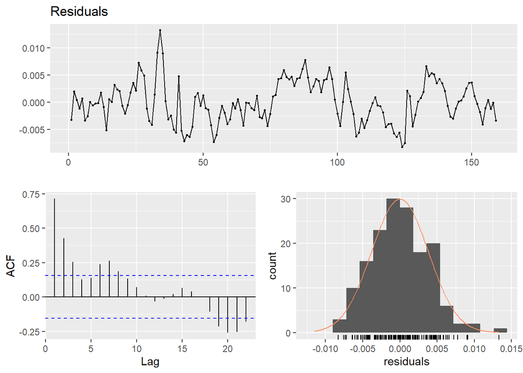

```r
checkresiduals(ts_reg$residuals)
```

• With the addition of the new variable, our adjusted R^2 value has increased and when the `summary` function is inspected, we see that our regressor is slightly significant with a p-value of 0.016.

• There isn’t a significant improvement on the residuals and we can still observe a high autocorrelation. We must work further on to improve the solidity of our initial assumptions of zero mean and constant variance.

### 2.3.6) Lag

• The ACF plot for residuals display a high lag1 value. In order to eliminate this autocorrelation in our model, we must add `lag1` to our model.

```r
alldata[, residuals:=residuals(ts_reg)]
alldata[, lag1:=shift(residuals(ts_reg),1)]

ts_reg=lm(log(CPI)~trend+month+log(USDexchange)+log(DomesticPPI)+InterestRates+lag1,alldata)
summary(ts_reg)
```

```
##
## Call:
## lm(formula = log(CPI) ~ trend + month + log(USDexchange) + log(DomesticPPI) +
##     InterestRates + lag1, data = alldata)
##
## Residuals:
##        Min         1Q     Median         3Q        Max
## -0.0087130 -0.0015598 -0.0001837  0.0014400  0.0088030
##
## Coefficients:
##                    Estimate Std. Error t value Pr(>|t|)
## (Intercept)       1.269e+00  1.822e-02  69.655  < 2e-16 ***
## trend             8.289e-04  2.437e-05  34.013  < 2e-16 ***
## monthAra          4.229e-03  1.102e-03   3.840 0.000186 ***
## monthEki          3.293e-03  1.101e-03   2.990 0.003293 **
## monthEyl          4.654e-06  1.101e-03   0.004 0.996634
## monthHaz          2.494e-03  1.102e-03   2.264 0.025099 *
## monthKas          3.202e-03  1.101e-03   2.907 0.004239 **
## monthMar          9.899e-03  1.083e-03   9.139 6.22e-16 ***
## monthMay          5.990e-03  1.102e-03   5.435 2.34e-07 ***
## monthNis          8.839e-03  1.102e-03   8.018 3.73e-13 ***
## monthOca          8.091e-03  1.102e-03   7.346 1.50e-11 ***
## monthŞub          9.643e-03  1.082e-03   8.914 2.28e-15 ***
## monthTem          1.331e-03  1.101e-03   1.209 0.228780
## log(USDexchange)  1.557e-02  2.886e-03   5.397 2.80e-07 ***
## log(DomesticPPI)  6.733e-02  3.750e-03  17.955  < 2e-16 ***
## InterestRates    -1.753e-04  5.848e-05  -2.998 0.003213 **
## lag1              7.193e-01  5.862e-02  12.271  < 2e-16 ***
## ---
## Signif. codes:  0 '***' 0.001 '**' 0.01 '*' 0.05 '.' 0.1 ' ' 1
##
## Residual standard error: 0.002807 on 141 degrees of freedom
##   (1 observation deleted due to missingness)
## Multiple R-squared:  0.9986, Adjusted R-squared:  0.9985
## F-statistic:  6335 on 16 and 141 DF,  p-value: < 2.2e-16
```

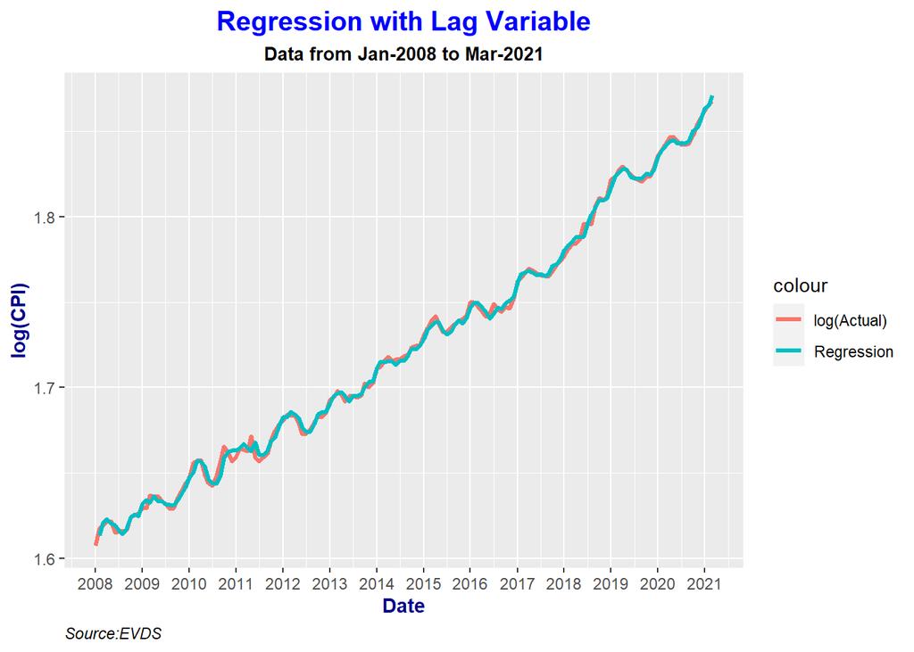

```r
alldata[,regrline:=predict(ts_reg,alldata)]

ggplot(data=alldata, aes(x=Date))+ geom_line(aes(y=log(CPI),color="log(Actual)"),size=1.2)+
  geom_line(aes(y=regrline,color='Regression'),size=1.2)+
  labs(title="Regression with Lag Variable",x = "Date",subtitle = "Data from Jan-2008 to Mar-2021",caption = "Source:EVDS") +
  theme(axis.title.y = element_text(color = "dark blue", face = "bold"),plot.title = element_text(color = "blue", size = 15, face = "bold",hjust=0.5),
        plot.subtitle = element_text(size = 10, face = "bold", hjust = 0.5), axis.title.x=element_text(colour="Dark Blue", face="bold"),
        plot.caption = element_text(face = "italic", hjust = 0))+
  scale_x_date(date_breaks = "1 year",labels=date_format("%Y"))
```

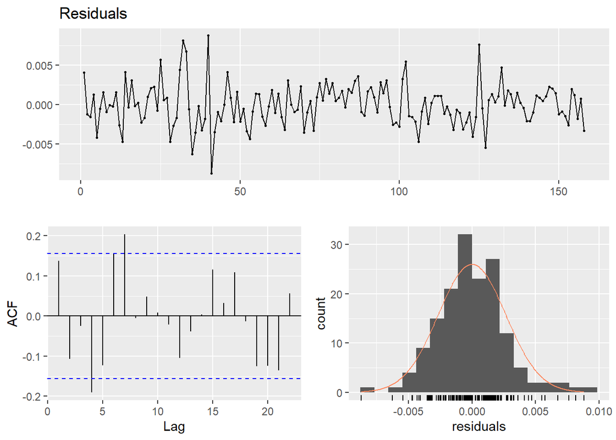

```r
checkresiduals(ts_reg$residuals)
```

• By inspecting the `summary()` function output, it can be concluded that the addition of the lag1 variable improved our model in terms of adjusted R^2 value and Residual Standard Error. Also the lag1 variable has a significant p-value of 2e-16.

• The benefit of adding `lag1` is also visible by looking at the plot of Actual vs Regression. Our predicted values are very close to the actual data.

## 2.4)Scatterplot Analysis

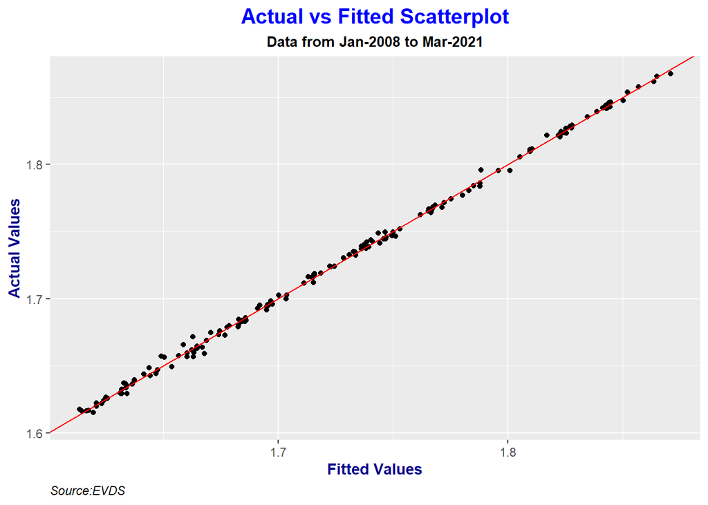

```r
ggplot(data=alldata)+ geom_point(aes(y=log(CPI), x=regrline))+
  labs(title="Actual vs Fitted Scatterplot",x = "Fitted Values",y="Actual Values",subtitle = "Data from Jan-2008 to Mar-2021",caption = "Source:EVDS") +
  theme(axis.title.y = element_text(color = "dark blue", face = "bold"),plot.title = element_text(color = "blue", size = 15, face = "bold",hjust=0.5),
        plot.subtitle = element_text(size = 10, face = "bold", hjust = 0.5), axis.title.x=element_text(colour="Dark Blue", face="bold"),
        plot.caption = element_text(face = "italic", hjust = 0)) + geom_abline(slope=1,color="red")
```

• From the first plots, it can be seen that the mean of residuals is close to 0 and the variance is constant except for a small number of outliers. Also, the last plot shows how well the predicted CPI fits the actual values.

## 2.5) Forecasting

• This study aims to forecast the CPI value in 2021-04, so we must first predict our regressors and than we can move on to predicting our target variable.

• For all independent variables, `predict` function is used to predict the values in 2021-4.

```r
alldata=rbind(alldata, data.table(Date= as.Date("2021-04-01")),fill=T)
alldata[160,trend:=160]

predict(alldata$USDexchange)
```

```
##     Point Forecast    Lo 80    Hi 80    Lo 95     Hi 95
## 160       7.706787 7.317995 8.095580 7.112181  8.301394
## 161       7.785390 7.222315 8.348466 6.924241  8.646540
## 162       7.863993 7.157992 8.569994 6.784258  8.943729
## 163       7.942596 7.108301 8.776892 6.666651  9.218541
## 164       8.021199 7.066924 8.975474 6.561761  9.480637
## 165       8.099802 7.030698 9.168906 6.464749  9.734855
## 166       8.178405 6.997788 9.359022 6.372807  9.984003
## 167       8.257008 6.967022 9.546994 6.284145 10.229871
## 168       8.335611 6.937606 9.733616 6.197547 10.473675
## 169       8.414214 6.908973 9.919455 6.112147 10.716281
```

```r
alldata[160, USDexchange:=7.706787]

predict(alldata$InterestRates)
```

```
##     Point Forecast     Lo 80    Hi 80      Lo 95    Hi 95
## 160       21.70647 19.901119 23.51182 18.9454246 24.46751
## 161       21.69166 18.405805 24.97751 16.6663797 26.71694
## 162       21.67981 16.875603 26.48401 14.3324113 29.02720
## 163       21.67033 15.340194 28.00046 11.9892240 31.35143
## 164       21.66274 13.821201 29.50429  9.6701383 33.65535
## 165       21.65668 12.330662 30.98269  7.3937683 35.91959
## 166       21.65182 10.874146 32.42950  5.1687878 38.13486
## 167       21.64794  9.453151 33.84273  2.9976196 40.29826
## 168       21.64483  8.066711 35.22296  0.8788864 42.41078
## 169       21.64235  6.712424 36.57228 -1.1910012 44.47570
```

```r
alldata[160, InterestRates:=21.70647]

predict(alldata$DomesticPPI)
```

```
##     Point Forecast    Lo 80    Hi 80    Lo 95    Hi 95
## 160       632.9363 621.7235 644.1490 615.7878 650.0847
## 161       647.6874 625.2313 670.1435 613.3438 682.0310
## 162       659.4883 624.8148 694.1619 606.4598 712.5169
## 163       668.9291 621.6530 716.2052 596.6265 741.2317
## 164       676.4817 616.5458 736.4176 584.8176 768.1458
## 165       682.5238 610.0641 754.9835 571.7062 793.3414
## 166       687.3575 602.6242 772.0907 557.7691 816.9458
## 167       691.2244 594.5336 787.9152 543.3485 839.1002
## 168       694.3179 586.0202 802.6157 528.6908 859.9451
## 169       696.7928 577.2533 816.3323 513.9729 879.6127
```

```r
alldata[160, DomesticPPI:=632.9363]

predict(alldata$lag1)
```

```
##     Point Forecast        Lo 80       Hi 80        Lo 95       Hi 95
## 160   -0.000101186 -0.003783538 0.003581166 -0.005732857 0.005530485
## 161   -0.000101186 -0.005308557 0.005106185 -0.008065173 0.007862801
## 162   -0.000101186 -0.006478781 0.006276409 -0.009854875 0.009652503
## 163   -0.000101186 -0.007465337 0.007262965 -0.011363683 0.011161311
## 164   -0.000101186 -0.008334516 0.008132144 -0.012692977 0.012490605
## 165   -0.000101186 -0.009120317 0.008917945 -0.013894756 0.013692384
## 166   -0.000101186 -0.009842937 0.009640565 -0.014999909 0.014797537
## 167   -0.000101186 -0.010515537 0.010313165 -0.016028562 0.015826190
## 168   -0.000101186 -0.011147258 0.010944886 -0.016994696 0.016792324
## 169   -0.000101186 -0.011744756 0.011542384 -0.017908489 0.017706117
```

```r
alldata[160, lag1:=-0.000101186]

alldata[160,month:=as.character(month(Date,label=1))]


ts_reg=lm(log(CPI)~trend+month+log(USDexchange)+log(DomesticPPI)+InterestRates+lag1,alldata)
summary(ts_reg)
```

```
##
## Call:
## lm(formula = log(CPI) ~ trend + month + log(USDexchange) + log(DomesticPPI) +
##     InterestRates + lag1, data = alldata)
##
## Residuals:
##        Min         1Q     Median         3Q        Max
## -0.0087130 -0.0015598 -0.0001837  0.0014400  0.0088030
##
## Coefficients:
##                    Estimate Std. Error t value Pr(>|t|)
## (Intercept)       1.269e+00  1.822e-02  69.655  < 2e-16 ***
## trend             8.289e-04  2.437e-05  34.013  < 2e-16 ***
## monthAra          4.229e-03  1.102e-03   3.840 0.000186 ***
## monthEki          3.293e-03  1.101e-03   2.990 0.003293 **
## monthEyl          4.654e-06  1.101e-03   0.004 0.996634
## monthHaz          2.494e-03  1.102e-03   2.264 0.025099 *
## monthKas          3.202e-03  1.101e-03   2.907 0.004239 **
## monthMar          9.899e-03  1.083e-03   9.139 6.22e-16 ***
## monthMay          5.990e-03  1.102e-03   5.435 2.34e-07 ***
## monthNis          8.839e-03  1.102e-03   8.018 3.73e-13 ***
## monthOca          8.091e-03  1.102e-03   7.346 1.50e-11 ***
## monthŞub          9.643e-03  1.082e-03   8.914 2.28e-15 ***
## monthTem          1.331e-03  1.101e-03   1.209 0.228780
## log(USDexchange)  1.557e-02  2.886e-03   5.397 2.80e-07 ***
## log(DomesticPPI)  6.733e-02  3.750e-03  17.955  < 2e-16 ***
## InterestRates    -1.753e-04  5.848e-05  -2.998 0.003213 **
## lag1              7.193e-01  5.862e-02  12.271  < 2e-16 ***
## ---
## Signif. codes:  0 '***' 0.001 '**' 0.01 '*' 0.05 '.' 0.1 ' ' 1
##
## Residual standard error: 0.002807 on 141 degrees of freedom
##   (2 observations deleted due to missingness)
## Multiple R-squared:  0.9986, Adjusted R-squared:  0.9985
## F-statistic:  6335 on 16 and 141 DF,  p-value: < 2.2e-16
```

```r
alldata[,regrline:=predict(ts_reg,alldata)]
```

• Our final plot shows that our model fits very closely with the actual data.

```r
forecast=exp(alldata$regrline[160])
forecast
```

```
## [1] 6.505008
```

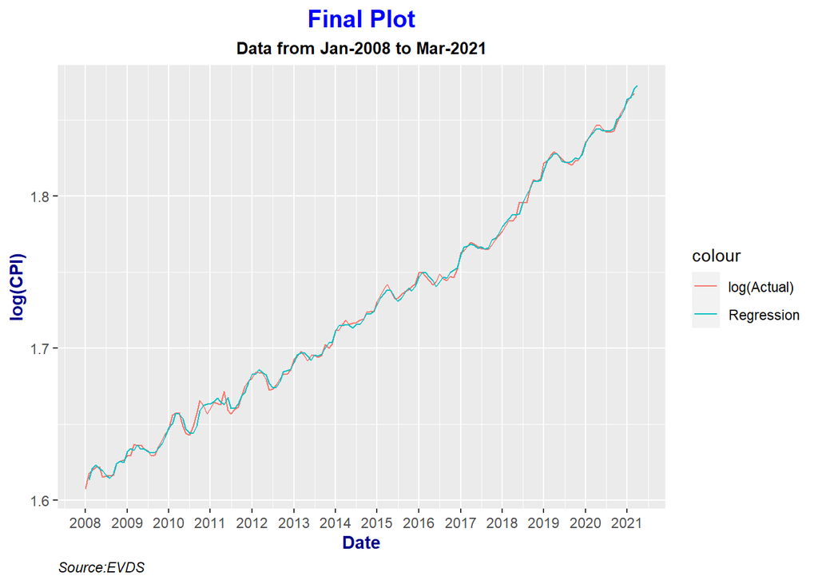

```r
ggplot(data=alldata, aes(x=Date))+ geom_line(aes(y=log(CPI),color="log(Actual)"))+
  geom_line(aes(y=regrline,color='Regression'))+
  labs(title="Final Plot",x = "Date",subtitle = "Data from Jan-2008 to Mar-2021",caption = "Source:EVDS") +
  theme(axis.title.y = element_text(color = "dark blue", face = "bold"),plot.title = element_text(color = "blue", size = 15, face = "bold",hjust=0.5),
        plot.subtitle = element_text(size = 10, face = "bold", hjust = 0.5), axis.title.x=element_text(colour="Dark Blue", face="bold"),
        plot.caption = element_text(face = "italic", hjust = 0))+
  scale_x_date(date_breaks = "1 year",labels=date_format("%Y"))
```

# 3) Conclusion

• In this study our aim was to build a model and forecast the future values of CPI(Food & Non-Alcoholic Beverages) using selected independet variables. Step by step we have included these parameters in our model by checking their significancy, correlation and the adjusted R^2 values after the model is created. We have also included trend and seasonality components and a lag variable in order to make our regression assumptions hold and decrease the autocorrelation.